# 重賞レース予測レポート【毎時自動更新中】

作成日時: 2026/02/01 15:06:21

☞ [マニュアル(pdf)](https://ryutoro-galois.github.io/keiba-predictor/manual/manual.pdf)

☞ 過去6年の同一レース結果: [2025年](https://ryutoro-galois.github.io/keiba-predictor/report/PredResult_2025y_raceDate_20250202_20250202.html), [2024年](https://ryutoro-galois.github.io/keiba-predictor/report/PredResult_2024y_raceDate_20240128_20240128.html), [2023年](https://ryutoro-galois.github.io/keiba-predictor/report/PredResult_2023y_raceDate_20230129_20230129.html), [2022年](https://ryutoro-galois.github.io/keiba-predictor/report/PredResult_2022y_raceDate_20220130_20220130.html), [2021年](https://ryutoro-galois.github.io/keiba-predictor/report/PredResult_2021y_raceDate_20210131_20210131.html), [2020年](https://ryutoro-galois.github.io/keiba-predictor/report/PredResult_2020y_raceDate_20200202_20200202.html)

☞ 過去4週間の別レース結果: [1週前(1/24-25)](https://ryutoro-galois.github.io/keiba-predictor/report/PredResult_2026y_raceDate_20260124_20260125.html), [2週前(1/18)](https://ryutoro-galois.github.io/keiba-predictor/report/PredResult_2026y_raceDate_20260118_20260118.html), [3週前(1/11-12)](https://ryutoro-galois.github.io/keiba-predictor/report/PredResult_2026y_raceDate_20260111_20260112.html), [4週前(1/4)](https://ryutoro-galois.github.io/keiba-predictor/report/PredResult_2026y_raceDate_20260104_20260104.html)

☞ netkeiba: [根岸ステークス(GⅢ)](https://race.netkeiba.com/race/shutuba.html?race_id=202605010211&rf=race_list), [シルクロードステークス(GⅢ)](https://race.netkeiba.com/race/shutuba.html?race_id=202608020211&rf=race_list)

## 0. 推し馬予測 (AI予測)

### 【根岸ステークス(GⅢ) 2026/02/01(日)】

- 本命(◎): 1-3着内確率(勝負強さ)が1位の馬
- 対抗(◯): 1-3着内確率が2-N位(20%程度以上)の中で予測タイムが最も速い馬
- 3番手(▲): 1-3着内確率が2-N位(20%程度以上)のでダークホース確率が最も高い馬
- 穴: ダークホース確率が上位1-M位(40%程度以上)の中で1-3着内確率が最も高い馬

| 推し馬 | 枠番 | 馬番 | 人気 | オッズ | 馬名 | 騎手 | 調教師 | 予測タイム(sec) | 1_順位 | 1-3着内確率(%) | 2_順位 | ﾀﾞｰｸﾎｰｽ確率(%) | 3_順位 |
| --- | --- | --- | --- | --- | --- | --- | --- | --- | --- | --- | --- | --- | --- |
| 本命(◎) | 1 | 1 | 3 | 4.8 | ウェイワードアクト | 戸崎圭太 | 田中博康 | 88.4 | 7 | 69.1 | 1 | 0.4 | 14 |
| 対抗(◯) | 2 | 3 | 5 | 9.3 | オメガギネス | 岩田康誠 | 安田翔伍 | 84.1 | 6 | 29.4 | 3 | 1.1 | 10 |
| 3番手(▲) | 5 | 9 | 2 | 4.2 | エンペラーワケア | 西村淳也 | 杉山晴紀 | 90.0 | 9 | 51.1 | 2 | 0.4 | 15 |
| 穴 | 3 | 5 | 10 | 30.8 | チカッパ | Ｒ．キング | 中竹和也 | 81.5 | 2 | 10.8 | 8 | 36.9 | 2 |

### 【シルクロードステークス(GⅢ) 2026/02/01(日)】

- 本命(◎): 1-3着内確率(勝負強さ)が1位の馬
- 対抗(◯): 1-3着内確率が2-N位(20%程度以上)の中で予測タイムが最も速い馬
- 3番手(▲): 1-3着内確率が2-N位(20%程度以上)のでダークホース確率が最も高い馬
- 穴: ダークホース確率が上位1-M位(40%程度以上)の中で1-3着内確率が最も高い馬

| 推し馬 | 枠番 | 馬番 | 人気 | オッズ | 馬名 | 騎手 | 調教師 | 予測タイム(sec) | 1_順位 | 1-3着内確率(%) | 2_順位 | ﾀﾞｰｸﾎｰｽ確率(%) | 3_順位 |
| --- | --- | --- | --- | --- | --- | --- | --- | --- | --- | --- | --- | --- | --- |
| 本命(◎) | 2 | 4 | 2 | 5.2 | カルプスペルシュ | 横山武史 | 石坂公一 | 70.2 | 9 | 44.4 | 1 | 0.5 | 17 |
| 対抗(◯) | 6 | 11 | 3 | 6.0 | ヤブサメ | 武豊 | 石橋守 | 69.1 | 6 | 39.0 | 2 | 0.7 | 16 |
| 3番手(▲) | 3 | 6 | 8 | 14.0 | ヤマニンアルリフラ | 団野大成 | 斉藤崇史 | 69.4 | 8 | 20.6 | 5 | 1.3 | 10 |
| 穴 | 2 | 3 | 15 | 71.6 | アルテヴェローチェ | 国分優作 | 須貝尚介 | 68.6 | 4 | 11.6 | 10 | 43.8 | 1 |

## 1. 予測チャート (タイム/勝負強さ)

### 【根岸ステークス(GⅢ)】

2026/02/01(日), 05_東京, ダ左1400m

[interactive chart not shown]

### 【シルクロードステークス(GⅢ)】

2026/02/01(日), 08_京都, 芝右1200m

[interactive chart not shown]

## 2. オッズモニタリング (毎時)

### 【根岸ステークス】

[interactive chart not shown]

### 【シルクロードステークス】

[interactive chart not shown]

## 3. 出馬表

### 【根岸ステークス 2026/02/01(日) 】

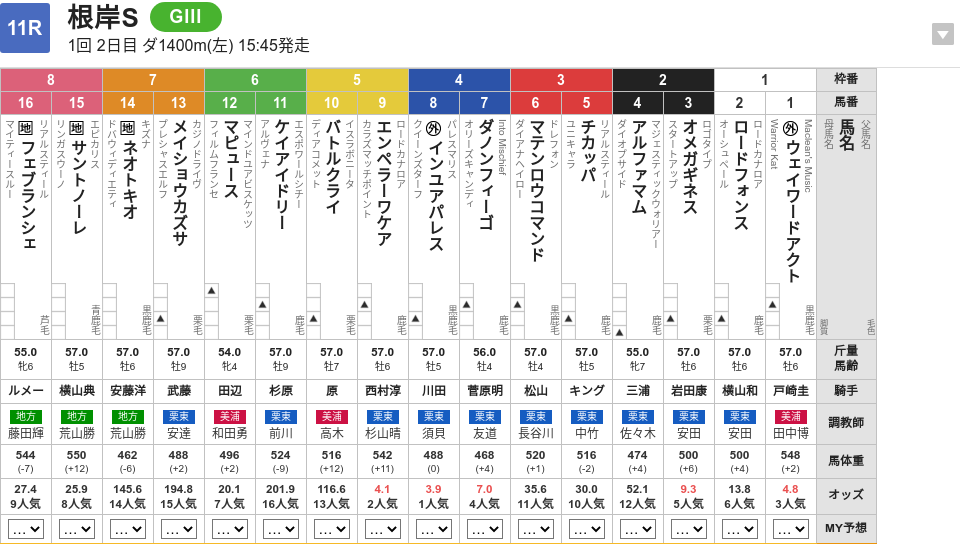

### 【シルクロードステークス 2026/02/01(日) 】

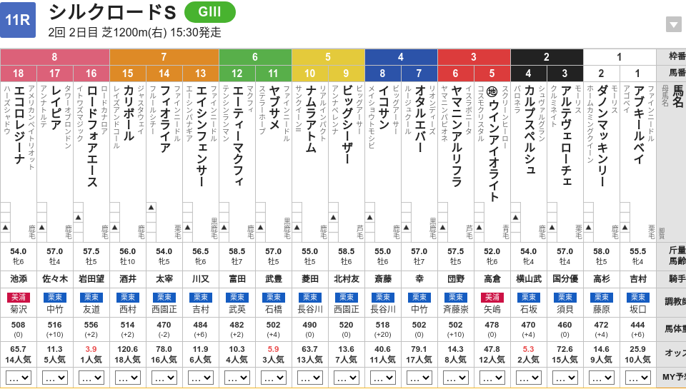

## 4. 単勝予測結果

### 【根岸ステークス(GⅢ) 2026/02/01(日)】

| 枠番 | 馬番 | 人気 | オッズ | 馬名 | 騎手 | 調教師 | 予測タイム(sec) | 1_順位 | 1-3着内確率(%) | 2_順位 | ﾀﾞｰｸﾎｰｽ確率(%) | 3_順位 |
| --- | --- | --- | --- | --- | --- | --- | --- | --- | --- | --- | --- | --- |
| 1 | 1 | 3 | 4.8 | ウェイワードアクト | 戸崎圭太 | 田中博康 | 88.4 | 7 | 69.1 | 1 | 0.4 | 14 |
| 1 | 2 | 6 | 13.9 | ロードフォンス | 横山和生 | 安田翔伍 | 89.7 | 8 | 10.1 | 9 | 1.0 | 11 |
| 2 | 3 | 5 | 9.3 | オメガギネス | 岩田康誠 | 安田翔伍 | 84.1 | 6 | 29.4 | 3 | 1.1 | 10 |
| 2 | 4 | 12 | 51.6 | アルファマム | 三浦皇成 | 佐々木晶三 | 90.1 | 10 | 2.5 | 13 | 9.6 | 8 |
| 3 | 5 | 10 | 30.8 | チカッパ | Ｒ．キング | 中竹和也 | 81.5 | 2 | 10.8 | 8 | 36.9 | 2 |
| 3 | 6 | 11 | 34.3 | マテンロウコマンド | 松山弘平 | 長谷川浩大 | 81.5 | 2 | 9.7 | 10 | 39.1 | 1 |
| 4 | 7 | 4 | 7.0 | ダノンフィーゴ | 菅原明良 | 友道康夫 | 91.6 | 14 | 26.5 | 4 | 0.3 | 16 |
| 4 | 8 | 1 | 3.9 | インユアパレス | 川田将雅 | 須貝尚介 | 81.5 | 2 | 19.2 | 5 | 0.4 | 13 |
| 5 | 9 | 2 | 4.2 | エンペラーワケア | 西村淳也 | 杉山晴紀 | 90.0 | 9 | 51.1 | 2 | 0.4 | 15 |
| 5 | 10 | 13 | 112.9 | バトルクライ | 原優介 | 高木登 | 91.5 | 13 | 1.6 | 16 | 30.0 | 3 |

[output cut: 6 more lines]

### 【シルクロードステークス(GⅢ) 2026/02/01(日)】

| 枠番 | 馬番 | 人気 | オッズ | 馬名 | 騎手 | 調教師 | 予測タイム(sec) | 1_順位 | 1-3着内確率(%) | 2_順位 | ﾀﾞｰｸﾎｰｽ確率(%) | 3_順位 |
| --- | --- | --- | --- | --- | --- | --- | --- | --- | --- | --- | --- | --- |
| 1 | 1 | 10 | 25.4 | アブキールベイ | 吉村誠之助 | 坂口智康 | 68.9 | 5.0 | 9.8 | 12 | 28.5 | 5 |
| 1 | 2 | 9 | 14.4 | ダノンマッキンリー | 高杉吏麒 | 藤原英昭 | 70.2 | 10.0 | 16.8 | 8 | 1.2 | 14 |
| 2 | 3 | 15 | 71.6 | アルテヴェローチェ | 国分優作 | 須貝尚介 | 68.6 | 4.0 | 11.6 | 10 | 43.8 | 1 |
| 2 | 4 | 2 | 5.2 | カルプスペルシュ | 横山武史 | 石坂公一 | 70.2 | 9.0 | 44.4 | 1 | 0.5 | 17 |
| 3 | 5 | 12 | 45.8 | ウインアイオライト | 高倉稜 | 矢嶋大樹 | 77.3 | 16.0 | 6.3 | 16 | 16.5 | 6 |
| 3 | 6 | 8 | 14.0 | ヤマニンアルリフラ | 団野大成 | 斉藤崇史 | 69.4 | 8.0 | 20.6 | 5 | 1.3 | 10 |
| 4 | 7 | 16 | 75.2 | オタルエバー | 幸英明 | 中竹和也 | 76.7 | 14.0 | 2.2 | 17 | 12.3 | 8 |
| 4 | 8 | 11 | 37.7 | イコサン | 斎藤新 | 長谷川浩大 | 69.2 | 7.0 | 9.2 | 14 | 31.5 | 4 |
| 5 | 9 | 7 | 13.8 | ビッグシーザー | 北村友一 | 西園正都 | 71.4 | 11.0 | 24.8 | 3 | 1.2 | 12 |
| 5 | 10 | 13 | 61.5 | ナムラアトム | 菱田裕二 | 長谷川浩大 | 72.4 | 13.0 | 9.3 | 13 | 33.4 | 3 |

[output cut: 8 more lines]

## 5. 人気と着順の乖離率推移

### 【根岸ステークス_1990y_2019y】

[interactive chart not shown]

### 【シルクロードステークス_1996y_2019y】

[interactive chart not shown]

### 【根岸ステークス_1990y_2019y】

| No | 開催年 | 不整合率(%) | 頭数 | 人気別着順(1-3位) | 人気別着順(全体) |
| --- | --- | --- | --- | --- | --- |
| 30 | 2019 | 38.8 | 16頭 | 2-3-5 | 2\|3\|5\|6\|12\|14\|11\|1\|9\|7\|15\|16\|4\|8\|10\|13 |
| 29 | 2018 | 22.0 | 13頭 | 6-1-2 | 6\|1\|2\|11\|5\|3\|10\|9\|12\|7\|13\|4\|8 |
| 28 | 2017 | 28.3 | 16頭 | 1-3-4 | 1\|3\|4\|5\|8\|11\|16\|6\|13\|14\|9\|2\|15\|10\|12\|7 |
| 27 | 2016 | 18.4 | 16頭 | 1-6-10 | 1\|6\|10\|2\|3\|5\|8\|9\|12\|7\|15\|13\|14\|4\|11\|16 |
| 26 | 2015 | 19.6 | 16頭 | 1-2-15 | 1\|2\|15\|8\|4\|7\|14\|3\|16\|10\|13\|9\|6\|5\|11\|12 |
| 25 | 2014 | 45.9 | 16頭 | 4-8-5 | 4\|8\|5\|1\|3\|14\|11\|2\|10\|12\|7\|9\|15\|6\|16\|13 |
| 24 | 2013 | 23.2 | 15頭 | 5-1-10 | 5\|1\|10\|12\|2\|8\|3\|9\|4\|13\|7\|15\|14\|11\|16 |
| 23 | 2012 | 49.1 | 15頭 | 4-9-5 | 4\|9\|5\|6\|1\|3\|10\|7\|8\|11\|13\|2\|12\|15\|14 |
| 22 | 2011 | 42.0 | 16頭 | 2-3-10 | 2\|3\|10\|8\|5\|9\|7\|1\|12\|16\|4\|11\|6\|15\|13\|14 |
| 21 | 2010 | 37.3 | 16頭 | 11-1-4 | 11\|1\|4\|3\|6\|7\|8\|12\|5\|10\|14\|9\|2\|13\|16\|15 |

[output cut: 20 more lines]

### 【シルクロードステークス_1996y_2019y】

| No | 開催年 | 不整合率(%) | 頭数 | 人気別着順(1-3位) | 人気別着順(全体) |
| --- | --- | --- | --- | --- | --- |
| 24 | 2019 | 42.3 | 18頭 | 1-11-12 | 1\|11\|12\|3\|10\|8\|6\|14\|7\|17\|4\|16\|15\|9\|5\|13\|18\|2 |
| 23 | 2018 | 68.9 | 18頭 | 4-5-15 | 4\|5\|15\|3\|6\|12\|7\|11\|17\|10\|2\|18\|13\|9\|8\|1\|16\|14 |
| 22 | 2017 | 64.8 | 13頭 | 3-4-7 | 3\|4\|7\|8\|6\|2\|11\|10\|9\|12\|1\|13\|5 |
| 21 | 2016 | 35.1 | 16頭 | 2-5-11 | 2\|5\|11\|10\|1\|4\|7\|12\|3\|9\|6\|16\|15\|13\|14\|8 |
| 20 | 2015 | 36.9 | 17頭 | 2-3-12 | 2\|3\|12\|4\|6\|16\|9\|17\|1\|7\|14\|5\|8\|10\|13\|11\|15 |
| 19 | 2014 | 26.1 | 16頭 | 2-1-13 | 2\|1\|13\|5\|10\|3\|6\|7\|12\|8\|4\|11\|15\|16\|14\|9 |
| 18 | 2013 | 55.0 | 16頭 | 2-4-11 | 2\|4\|11\|6\|15\|5\|7\|9\|10\|13\|14\|12\|8\|3\|1\|16 |
| 17 | 2012 | 21.4 | 16頭 | 1-2-16 | 1\|2\|16\|12\|5\|7\|14\|6\|9\|8\|10\|11\|15\|13\|3\|4 |
| 16 | 2011 | 34.2 | 16頭 | 1-14-4 | 1\|14\|4\|6\|12\|3\|2\|10\|5\|11\|13\|8\|16\|15\|9\|7 |
| 15 | 2010 | 53.2 | 16頭 | 3-4-6 | 3\|4\|6\|9\|7\|5\|16\|1\|12\|11\|8\|13\|15\|14\|2\|10 |

[output cut: 14 more lines]

## 6. 1-3番人気馬の着順分類予測

### 【根岸ステークス】

| 分類 | 凡例 | 発生確率(%) | 当該レース | 当該レースランク | 直近1年間 |
| --- | --- | --- | --- | --- | --- |
| 1: 1番人気のみ (1_pop1) | 1 \| * \| * | 16.5 | 0.74 | 0.78 | 0.00 |
| 8: 1,2,3番人気すべて着外 (8_darkhorse) | * \| * \| * | 15.5 | 0.80 | 0.64 | 0.31 |
| 4: 1,2番人気のみ (4_pop12) | 1 \| 2 \| * | 15.4 | 1.11 | 1.13 | 0.00 |
| 6: 2,3番人気のみ (6_pop23) | 2 \| 3 \| * | 13.5 | 0.61 | 0.89 | 0.27 |
| 5: 1,3番人気のみ (5_pop13) | 1 \| 3 \| * | 12.9 | 1.16 | 2.11 | 0.00 |
| 3: 3番人気のみ (3_pop3) | 3 \| * \| * | 10.4 | 1.25 | 0.86 | 0.00 |
| 2: 2番人気のみ (2_pop2) | 2 \| * \| * | 8.7 | 0.00 | 1.43 | 0.00 |
| 7: 1,2,3番人気すべて着内 (7_pop123) | 1 \| 2 \| 3 | 7.1 | 2.54 | 4.73 | 0.00 |

### 【シルクロードステークス】

| 分類 | 凡例 | 発生確率(%) | 当該レース | 当該レースランク | 直近1年間 |
| --- | --- | --- | --- | --- | --- |
| 8: 1,2,3番人気すべて着外 (8_darkhorse) | * \| * \| * | 21.8 | 0.73 | 0.90 | 0.44 |
| 1: 1番人気のみ (1_pop1) | 1 \| * \| * | 16.1 | 0.80 | 0.76 | 0.00 |
| 4: 1,2番人気のみ (4_pop12) | 1 \| 2 \| * | 15.0 | 1.13 | 1.10 | 0.00 |
| 5: 1,3番人気のみ (5_pop13) | 1 \| 3 \| * | 12.7 | 0.00 | 2.08 | 0.00 |
| 3: 3番人気のみ (3_pop3) | 3 \| * \| * | 10.2 | 0.61 | 0.84 | 0.00 |
| 2: 2番人気のみ (2_pop2) | 2 \| * \| * | 8.6 | 0.65 | 1.41 | 0.00 |
| 6: 2,3番人気のみ (6_pop23) | 2 \| 3 \| * | 8.6 | 1.28 | 0.57 | 0.17 |
| 7: 1,2,3番人気すべて着内 (7_pop123) | 1 \| 2 \| 3 | 7.0 | 0.00 | 4.67 | 0.00 |

## 7. 3連複予測結果

### 【根岸ステークス(GⅢ) 2026/02/01(日)】

| 分類 | 馬番 | 枠番 | 人気 | 平均予測タイム(sec) | 1-3着内確率(%) | ﾀﾞｰｸﾎｰｽ確率(%) | 馬名 | 騎手 | 調教師 |
| --- | --- | --- | --- | --- | --- | --- | --- | --- | --- |
| 6: 2,3番人気のみ (6_pop23) | 9-1-3 | 5-1-2 | 2-3-5 | 87.50 | 10.38 | 0.00 | エンペラーワケア \| ウェイワードアクト \| オメガギネス | 西村淳也 \| 戸崎圭太 \| 岩田康誠 | 杉山晴紀 \| 田中博康 \| 安田翔伍 |
| 6: 2,3番人気のみ (6_pop23) | 9-1-7 | 5-1-4 | 2-3-4 | 90.00 | 9.36 | 0.00 | エンペラーワケア \| ウェイワードアクト \| ダノンフィーゴ | 西村淳也 \| 戸崎圭太 \| 菅原明良 | 杉山晴紀 \| 田中博康 \| 友道康夫 |
| 7: 1,2,3番人気すべて着内 (7_pop123) | 8-9-1 | 4-5-1 | 1-2-3 | 86.63 | 6.79 | 0.00 | インユアパレス \| エンペラーワケア \| ウェイワードアクト | 川田将雅 \| 西村淳也 \| 戸崎圭太 | 須貝尚介 \| 杉山晴紀 \| 田中博康 |
| 6: 2,3番人気のみ (6_pop23) | 9-1-12 | 5-1-6 | 2-3-7 | 87.27 | 6.56 | 0.00 | エンペラーワケア \| ウェイワードアクト \| マピュース | 西村淳也 \| 戸崎圭太 \| 田辺裕信 | 杉山晴紀 \| 田中博康 \| 和田勇介 |
| 3: 3番人気のみ (3_pop3) | 1-7-3 | 1-4-2 | 3-4-5 | 88.03 | 5.39 | 0.00 | ウェイワードアクト \| ダノンフィーゴ \| オメガギネス | 戸崎圭太 \| 菅原明良 \| 岩田康誠 | 田中博康 \| 友道康夫 \| 安田翔伍 |
| 6: 2,3番人気のみ (6_pop23) | 9-1-15 | 5-1-8 | 2-3-8 | 86.67 | 4.78 | 0.00 | エンペラーワケア \| ウェイワードアクト \| サントノーレ | 西村淳也 \| 戸崎圭太 \| 横山典弘 | 杉山晴紀 \| 田中博康 \| 荒山勝徳 |
| 2: 2番人気のみ (2_pop2) | 9-7-3 | 5-4-2 | 2-4-5 | 88.57 | 3.99 | 0.00 | エンペラーワケア \| ダノンフィーゴ \| オメガギネス | 西村淳也 \| 菅原明良 \| 岩田康誠 | 杉山晴紀 \| 友道康夫 \| 安田翔伍 |
| 5: 1,3番人気のみ (5_pop13) | 8-1-3 | 4-1-2 | 1-3-5 | 84.67 | 3.91 | 0.00 | インユアパレス \| ウェイワードアクト \| オメガギネス | 川田将雅 \| 戸崎圭太 \| 岩田康誠 | 須貝尚介 \| 田中博康 \| 安田翔伍 |
| 6: 2,3番人気のみ (6_pop23) | 9-1-5 | 5-1-3 | 2-3-10 | 86.63 | 3.81 | 0.00 | エンペラーワケア \| ウェイワードアクト \| チカッパ | 西村淳也 \| 戸崎圭太 \| Ｒ．キング | 杉山晴紀 \| 田中博康 \| 中竹和也 |
| 3: 3番人気のみ (3_pop3) | 1-3-12 | 1-2-6 | 3-5-7 | 85.30 | 3.78 | 0.00 | ウェイワードアクト \| オメガギネス \| マピュース | 戸崎圭太 \| 岩田康誠 \| 田辺裕信 | 田中博康 \| 安田翔伍 \| 和田勇介 |

[output cut: 550 more lines]

### 【シルクロードステークス(GⅢ) 2026/02/01(日)】

| 分類 | 馬番 | 枠番 | 人気 | 平均予測タイム(sec) | 1-3着内確率(%) | ﾀﾞｰｸﾎｰｽ確率(%) | 馬名 | 騎手 | 調教師 |
| --- | --- | --- | --- | --- | --- | --- | --- | --- | --- |
| 6: 2,3番人気のみ (6_pop23) | 4-11-9 | 2-6-5 | 2-3-7 | 70.23 | 4.30 | 0.00 | カルプスペルシュ \| ヤブサメ \| ビッグシーザー | 横山武史 \| 武豊 \| 北村友一 | 石坂公一 \| 石橋守 \| 西園正都 |
| 6: 2,3番人気のみ (6_pop23) | 4-11-17 | 2-6-8 | 2-3-5 | 70.23 | 3.74 | 0.00 | カルプスペルシュ \| ヤブサメ \| レイピア | 横山武史 \| 武豊 \| 佐々木大輔 | 石坂公一 \| 石橋守 \| 中竹和也 |
| 6: 2,3番人気のみ (6_pop23) | 4-11-6 | 2-6-3 | 2-3-8 | 69.57 | 3.57 | 0.00 | カルプスペルシュ \| ヤブサメ \| ヤマニンアルリフラ | 横山武史 \| 武豊 \| 団野大成 | 石坂公一 \| 石橋守 \| 斉藤崇史 |
| 6: 2,3番人気のみ (6_pop23) | 4-11-13 | 2-6-7 | 2-3-6 | 69.30 | 3.41 | 0.00 | カルプスペルシュ \| ヤブサメ \| エイシンフェンサー | 横山武史 \| 武豊 \| 川又賢治 | 石坂公一 \| 石橋守 \| 吉村圭司 |
| 7: 1,2,3番人気すべて着内 (7_pop123) | 16-4-11 | 8-2-6 | 1-2-3 | 68.90 | 2.96 | 0.00 | ロードフォアエース \| カルプスペルシュ \| ヤブサメ | 岩田望来 \| 横山武史 \| 武豊 | 友道康夫 \| 石坂公一 \| 石橋守 |
| 6: 2,3番人気のみ (6_pop23) | 4-11-2 | 2-6-1 | 2-3-9 | 69.83 | 2.91 | 0.00 | カルプスペルシュ \| ヤブサメ \| ダノンマッキンリー | 横山武史 \| 武豊 \| 高杉吏麒 | 石坂公一 \| 石橋守 \| 藤原英昭 |
| 6: 2,3番人気のみ (6_pop23) | 4-11-12 | 2-6-6 | 2-3-4 | 72.37 | 2.61 | 0.00 | カルプスペルシュ \| ヤブサメ \| エーティーマクフィ | 横山武史 \| 武豊 \| 富田暁 | 石坂公一 \| 石橋守 \| 武英智 |
| 2: 2番人気のみ (2_pop2) | 4-17-9 | 2-8-5 | 2-5-7 | 71.00 | 2.38 | 0.00 | カルプスペルシュ \| レイピア \| ビッグシーザー | 横山武史 \| 佐々木大輔 \| 北村友一 | 石坂公一 \| 中竹和也 \| 西園正都 |
| 2: 2番人気のみ (2_pop2) | 4-9-6 | 2-5-3 | 2-7-8 | 70.33 | 2.27 | 0.00 | カルプスペルシュ \| ビッグシーザー \| ヤマニンアルリフラ | 横山武史 \| 北村友一 \| 団野大成 | 石坂公一 \| 西園正都 \| 斉藤崇史 |
| 2: 2番人気のみ (2_pop2) | 4-13-9 | 2-7-5 | 2-6-7 | 70.07 | 2.17 | 0.00 | カルプスペルシュ \| エイシンフェンサー \| ビッグシーザー | 横山武史 \| 川又賢治 \| 北村友一 | 石坂公一 \| 吉村圭司 \| 西園正都 |

[output cut: 806 more lines]

## 8. 直近の全レース情報

[output not shown]